# Google Analytics Customer Revenue Prediction

Forensic and Forecasting Analytics Project

Joyce Ng Yuan Cheng, Clarice Yeo Pei Si, Then Jia Hui, Jerome Jeevan Naidu, Gavin Ong Ze Kai

2018-11-12

Table of Contents

1. Executive Summary
2. Data Cleaning
3. Exploratory Data Analysis  
   3.1 Missing values  
   3.2 Duplicates in sessionId  
   3.3 Plotting of Variables Against Average Transaction Revenue  
   3.3.1 Continents  
   3.3.2 Sub Continents  
   3.3.3 Channel Grouping  
   3.3.4 Medium Dimension  
   3.3.5 Device Categories  
   3.3.6 isMobile  
   3.3.7 Operating Systems  
   3.3.8 Hits and Pageviews  
   3.4 Correlation Matrix
4. Model Selection  
   4.1 Choice of error metric  
   4.2 LASSO  
   4.2.1 LASSO Model Evaluation  
   4.3 Random Forest  
   4.3.1 Random Forest Model Evaluation  
   4.4 Insights from initial models
5. Classification of users into paying and non-paying
6. Exploratory Data Analysis (Part II)  
   6.1 Channel Grouping  
   6.2 Medium  
   6.3 Device Category  
   6.4 Operating System  
   6.5 Continent  
   6.6 subContinent  
   6.7 Country  
   6.8 Pageviews & hits  
   6.9 Browser
7. Model Evaluation & Refinement  
   7.1 Feature engineering  
   7.2 Revised Random Forest Model  
   7.3 Trial of new model - Gradient Boosting Machines (GBM)
8. Conclusion
9. References

```r
# Load libraries
library(tidyverse)
library(jsonlite)
library(randomForest)
library(lattice)
library(data.table)
library(caret)
library(lubridate)
library(readr)
```

# 1. Executive Summary

This report documents our group’s participation in an ongoing Kaggle competition to analyse a Google Merchandise Store customer dataset to predict the revenue per customer. We started off by conducting an Exploratory Data Analysis (EDA) on the train data to eliminate variables with large amounts of missing data and to analyse the usefulness of variables we expect to have an impact on transaction revenue.

Running LASSO on the variables we found to be useful gave us a root mean square error (RMSE) of 1.6410, placing us at 2839th in the competition. However, our group realised that a regression analysis may not be the best option as some of the variables are categorical variables which LASSO is not equipped to handle. Understanding that this is in fact a classification and regression data science project, we then opted to use the Random Forest algorithm. This gave us a RMSE of 1.6472. Using the %IncMSE measure in Random Forest also helped us to identify variables that higher predictive power - pageviews, subContinent and hits.

Reflecting on the results of our first 2 models, we realised that due to the very small proportion of visits with any revenue (1.27%), a two-part model that first identifies whether the customer will make a transaction before predicting the revenue of such a customer will be more accurate.

Our group proceeded to do a second EDA by splitting the train data into visitors who made transactions and visitors who did not. We discovered a few variables that have predictive power of transaction revenue and hence feature engineered 2 variables (browser == Chrome, and deviceCategory == desktop & operatingSystem == “Chrome OS”, “Macintosh” or “Linux”). Using this revised Random Forest Model, RMSE was reduced to 1.5616.

We decided to use Gradient Boosting Machines (GBM) in our final model as it performs better than Random Forest if the parameters are carefully tuned. Using the same variables, we achieved an ultimate Kaggle RMSE of 1.5387, ranking us at 2739th.

# 2. Data Cleaning

Before analysis of the data, we performed the following steps to clean the dataset provided:

1. Flatten columns
2. Change all observations with NA-related strings to NA
3. Assign 0 to the NA values of transaction revenue (for train data set), pageviews, bounces and newVisits as these are numerical variables that should either be zero or have a number
4. Assign “Not Set” to the NA values of other categorical variables
5. Convert appropriate variables to date, factor and numeric
6. Apply log transformation on transactionRevenue from train data set

   Code taken from https://www.kaggle.com/mrknoot/gstore-crafting-models-manual-features-xgb).

```r
# Load datasets & flatten columns

flatten <- function(x){
  pre_flatten <- . %>%
    str_c(., collapse = ",") %>%
    str_c("[", ., "]") %>%
    fromJSON(flatten = T)

  output <- x %>%
    bind_cols(pre_flatten(.$device)) %>%
    bind_cols(pre_flatten(.$geoNetwork)) %>%
    bind_cols(pre_flatten(.$trafficSource)) %>%
    bind_cols(pre_flatten(.$totals)) %>%
    select(-device, -geoNetwork, -trafficSource, -totals)

  return(output)
}

train <- read_csv("train.csv")  %>% flatten() %>% data.frame()
test  <- read_csv("test.csv")   %>%  flatten() %>% data.frame()
```

```r
# Change all observations with NA-related strings to NA

hidden_na <- function(x) x %in% c("not available in demo dataset",
                                  "(not provided)",
                                  "(not set)",
                                  "<NA>",
                                  "unknown.unknown",
                                  "(none)",
                                  "Not Socially Engaged")

train <- train %>%  mutate_all(funs(ifelse(hidden_na(.), NA, .))) %>% data.frame()
test  <- test  %>%  mutate_all(funs(ifelse(hidden_na(.), NA, .))) %>% data.frame()

# Remove all columns with 100% missing data

train <- train[,which(unlist(lapply(train, function(x)!all(is.na(x)))))]
test  <- test[,which(unlist(lapply(test, function(x)!all(is.na(x)))))]
```

```r
# Cleaning observations with NA variables
# NAs to zeros & "Not Set" - category created for observations with
# missing categories


train$transactionRevenue[is.na(train$transactionRevenue)] <- 0
train$bounces[which(is.na(train$bounces))] <- 0
test$bounces[which(is.na(test$bounces))] <- 0
train$newVisits[which(is.na(train$newVisits))] <- 0
test$newVisits[which(is.na(test$newVisits))] <- 0
train$pageviews[which(is.na(train$pageviews))] <- 0
test$pageviews[which(is.na(test$pageviews))] <- 0


train$continent[which(is.na(train$continent))] <- "Not Set"
test$continent[which(is.na(test$continent))] <- "Not Set"
train$subContinent[which(is.na(train$subContinent))] <- "Not Set"
test$subContinent[which(is.na(test$subContinent))] <- "Not Set"
train$country[which(is.na(train$country))] <- "Not Set"
test$country[which(is.na(test$country))] <- "Not Set"
train$medium[which(is.na(train$medium))] <- "Not Set"
test$medium[which(is.na(test$medium))] <- "Not Set"
train$operatingSystem[which(is.na(train$operatingSystem))] <- "Not Set"
test$operatingSystem[which(is.na(test$operatingSystem))] <- "Not Set"
train$browser[which(is.na(train$browser))] <- "Not Set"
test$browser[which(is.na(test$browser))] <- "Not Set"
train$source[which(is.na(train$source))] <- "Not Set"
test$source[which(is.na(test$source))] <- "Not Set"
```

```r
# Convert appropriate variables to date, factor and numeric

train$date<- ymd(train$date)
test$date <- ymd(test$date)

train$visitId <-
 as.character(train$visitId)

train$visitStartTime <- as.POSIXct(train$visitStartTime, origin = "1970-01-01")
test$visitStartTime <- as.POSIXct(test$visitStartTime, origin = "1970-01-01")

train[,c("channelGrouping", "browser",
         "operatingSystem", "deviceCategory", "continent",
         "subContinent", "country", "source", "medium", "keyword",
         "referralPath", "campaign")]<-
  lapply(train[,c("channelGrouping", "browser",
                  "operatingSystem", "deviceCategory", "continent",
                  "subContinent", "country", "source", "medium",
                  "keyword", "referralPath", "campaign"
  )], as.factor)

test[,c("channelGrouping", "browser",
         "operatingSystem", "deviceCategory", "continent",
         "subContinent", "country", "source", "medium", "keyword",
         "referralPath", "campaign")]<-
  lapply(test[,c("channelGrouping", "browser",
                  "operatingSystem", "deviceCategory", "continent",
                  "subContinent", "country", "source", "medium",
                  "keyword", "referralPath", "campaign"
  )], as.factor)



train[,c("visits", "hits", "pageviews", "bounces", "newVisits", "visitNumber",
         "transactionRevenue")]<-
  lapply(train[,c("visits","hits", "pageviews", "bounces", "newVisits",
                  "visitNumber" , "transactionRevenue"
  )], as.numeric)

test[,c("visits", "hits", "pageviews", "bounces", "newVisits", "visitNumber")]<-
  lapply(test[,c("visits", "hits", "pageviews", "bounces", "newVisits", "visitNumber"
  )], as.numeric)

# Calculate log of transaction revenue
train$log_transactionRevenue <- log1p(train$transactionRevenue)


saveRDS(train, 'train.rds')
saveRDS(test, 'test.rds')
```

# 3. Exploratory Data Analysis

We will be conducting exploratory data analysis using the train data. This would help us to gain a better understanding of our data and to choose the variables to be included in our model later on. It also helps us to understand the missing values or discrepancies we have in our data so that we can do some data cleaning before we proceed on with modelling.

## 3.1 Missing values

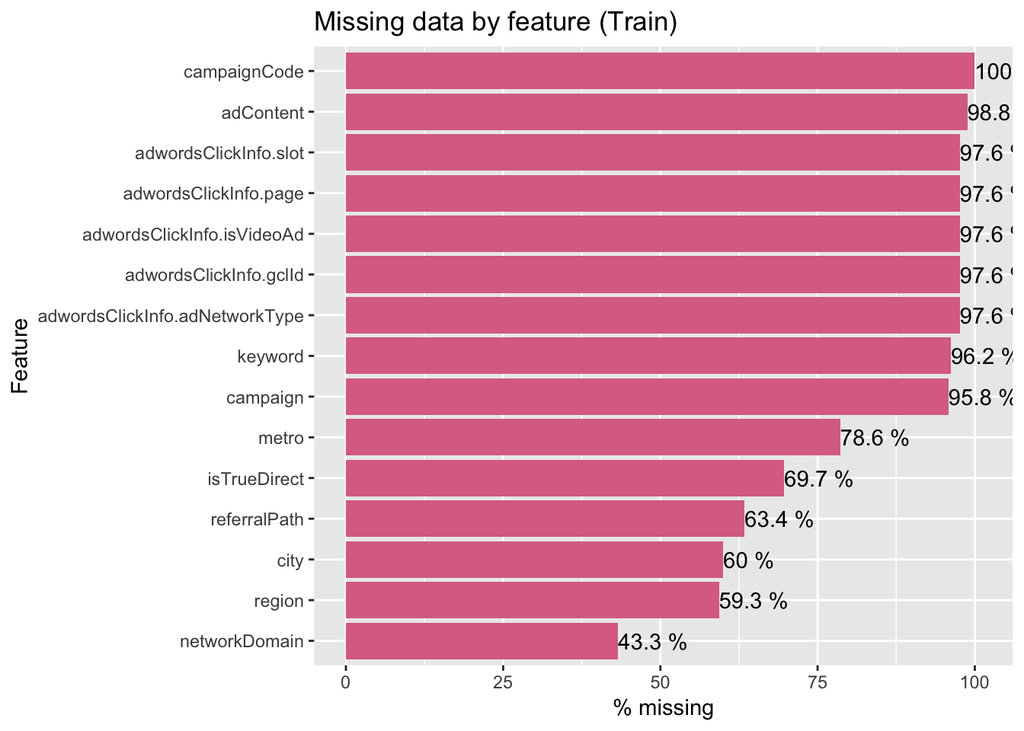

```r
# Load RDS
train <- readRDS('train.rds')
test <- readRDS('test.rds')

colNA <- which(colSums(is.na(train)) > 0)
colNAcount <- round(colSums(sapply(train[colNA],is.na))/nrow(train)*100,1)
missingtrain <- data.frame(columns=names(colNA), no.missing=colNAcount) %>%
  arrange(desc(colNAcount))

missingtrain %>%
  ggplot(aes(x=reorder(columns, no.missing), y=no.missing)) +
  geom_bar(stat = "identity", fill = "palevioletred") +
  coord_flip(y=c(0,101))+
  geom_text(aes(label=paste(no.missing, "%"), hjust=-0.0001)) +
  labs(
    title='Missing data by feature (Train)',
    x='Feature',
    y='% missing')
```

*Treatment*:

We will be removing campaignCode, all adwordsClickInfo.(Parameters), adContent, due to the large amount of missing values.

These following variables will be removed as well due to them having only category == “not available in demo dataset” : browserVersion, browserSize, operatingSystemVersion, mobileDeviceBranding, mobileDeviceModel, mobileInputSelector, mobileDeviceInfo, flashVersion, language, screenColors, screenResolution. While for socialEngagementType, the only level is not socially engaged and hence it will be removed as well.

The variable visits only have one value which 1 hence we will be removing it as well.

We will be removing these variables - region, Metro, City, cityId, latitude, longitude, networkLocation, because continents and subcontinents variables will be used as location information variables. As these variables have a large number of levels, the number of observations for each level may not be sufficient and hence negatively impacting the usefulness of these variables in predicting revenue for each sessionId.

## 3.2 Duplicates in sessionId

*Insights*:

The total number of observations in train set is 903,653. Our group checked for the number of unique sessionId since it is supposed to be an unique identifier. The output returned is 902,755 which means there are 898 duplicates in sessionId.

All duplicated sessionId appeared twice. However, when we checked through the duplicated observations, they are almost the same except for visitStartTime, visits, hits, pageviews, bounces, newVisits. A possible explanation is that the users might have opened another browser. It could be due to time zone differences where it is a single session but the session extends beyond midnight to the next day.

## 3.3 Plotting of Variables against Average Transaction Revenue

*Explanation*:

We are taking the average of transaction revenue as our y-axis for the following plots. This is because the number of transactions with revenue takes up only 1.27% (11,515 out of the 903,653 observations) of the train dataset. If we were to just analyse by the revenue earned, it may result in an inaccurate representation as a single large spending by a certain sessionId will cause the analysis to be skewed. On the other hand, if the number of transactions is used as the dependent variable, we will only be analysing the number of transactions made but not the amount spent each time.

Hence, the average transaction revenue is a better indicator to use when comparing the performance of each independent variables and we will use it to further predict the revenue earned for each sessionId.

The following graphs that were plotted are based on a pick of variables which we expect to be correlated with transaction revenue.

## 3.3.1 Continents

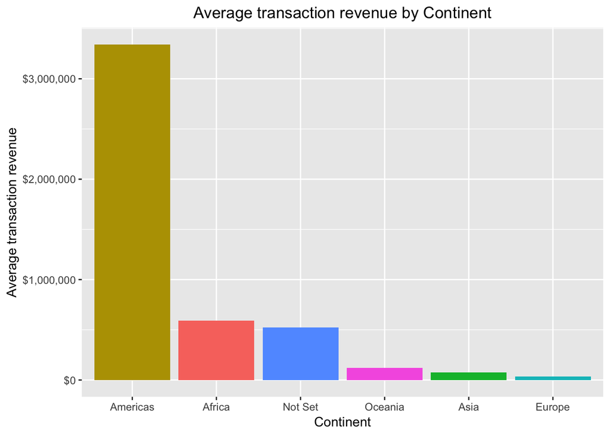

```r
plotcontinent <- train %>%
  group_by(continent) %>%
  mutate(avg_revenue=mean(transactionRevenue)) %>%
  slice(1) %>%
  ungroup() %>%
  ggplot(aes(x=reorder(continent, -avg_revenue), y=avg_revenue, fill=continent)) +
  geom_col() +
  scale_y_continuous(label=scales::dollar)+
  theme(plot.title = element_text(hjust = 0.5), legend.position="none")+
  ggtitle("Average transaction revenue by Continent") +
  labs(
    x='Continent',
    y='Average transaction revenue')
plotcontinent
```

## 3.3.2 Sub Continents

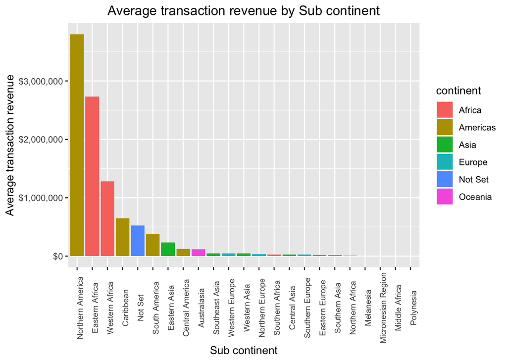

```r
plotsubcontinent <- train %>%
  group_by(subContinent) %>%
  mutate(avg_revenue=mean(transactionRevenue)) %>%
  slice(1) %>%
  ungroup() %>%
  ggplot(aes(x=reorder(subContinent, -avg_revenue), y=avg_revenue, fill=continent)) +
  geom_col() +
  scale_y_continuous(label=scales::dollar)+
  theme(plot.title = element_text(hjust = 0.5),
        axis.text.x = element_text(angle=90, size=8)) +
  ggtitle("Average transaction revenue by Sub continent") +
  labs(
    x='Sub continent',
    y='Average transaction revenue')
plotsubcontinent
```

*Insights*:

To gain a better understanding from the previous graph, we analysed the average transaction revenue by subcontinent instead. This breaks the data further into smaller groups. From 3.3.1 Continents, we concluded that the Americas took the top spot in having the highest average transaction revenue. However, as we split the data further into subcontinents, Northern America actually has the highest average transaction revenue, followed by Eastern Africa and Western Africa.

However, from the graph we can infer that the other parts of the America continents, such as Caribbean, South America, Central America, do not generate a significant amount of revenue. Hence, subcontinent may be a more specific and accurate indicator of revenue transacted as compared to continent. This is because when continents are used, we may be quick to conclude that all of Americas’ subcontinents are significant contributors of the revenue earned.

## 3.3.3 Channel Grouping

Explanation from https://support.google.com/analytics/answer/1033173?hl=en&ref_topic=6010089

Refer to table in word report for the explanation of categories.

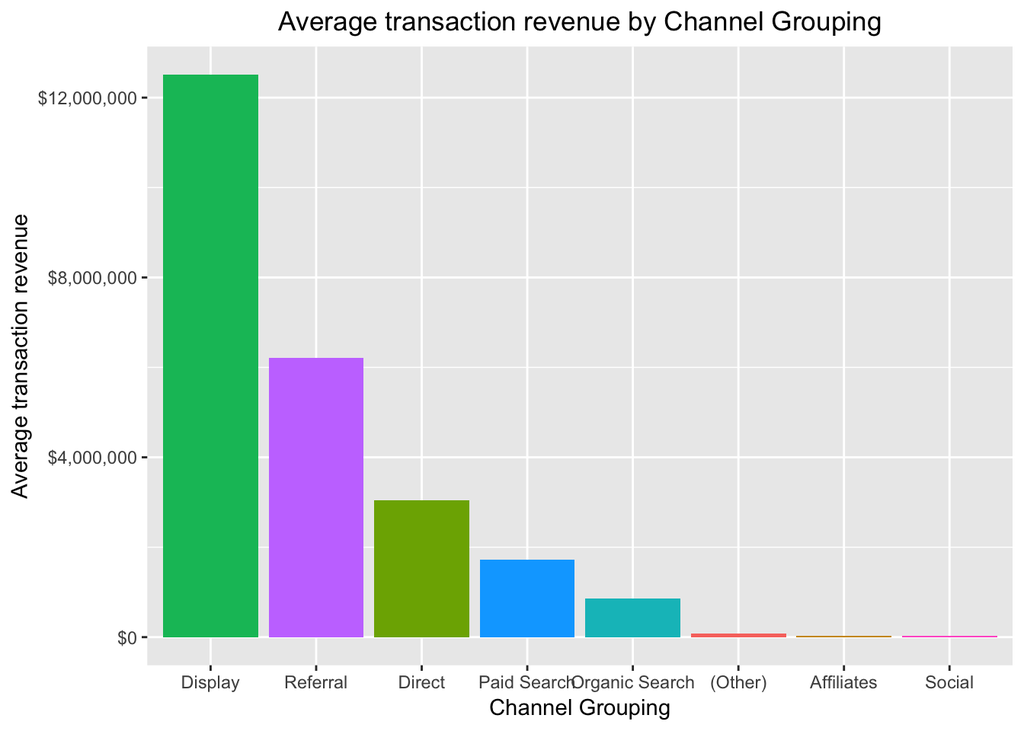

```r
plotCG <- train %>%
  group_by(channelGrouping) %>%
  mutate(avg_revenue=mean(transactionRevenue)) %>%
  slice(1) %>%
  ungroup() %>%
  ggplot(aes(x=reorder(channelGrouping, -avg_revenue), y=avg_revenue, fill=channelGrouping)) +
  geom_col() +
  scale_y_continuous(label=scales::dollar)+
  theme(plot.title = element_text(hjust = 0.5), legend.position = "none")+
  ggtitle("Average transaction revenue by Channel Grouping") +
  labs(
    x='Channel Grouping',
    y='Average transaction revenue')
plotCG
```

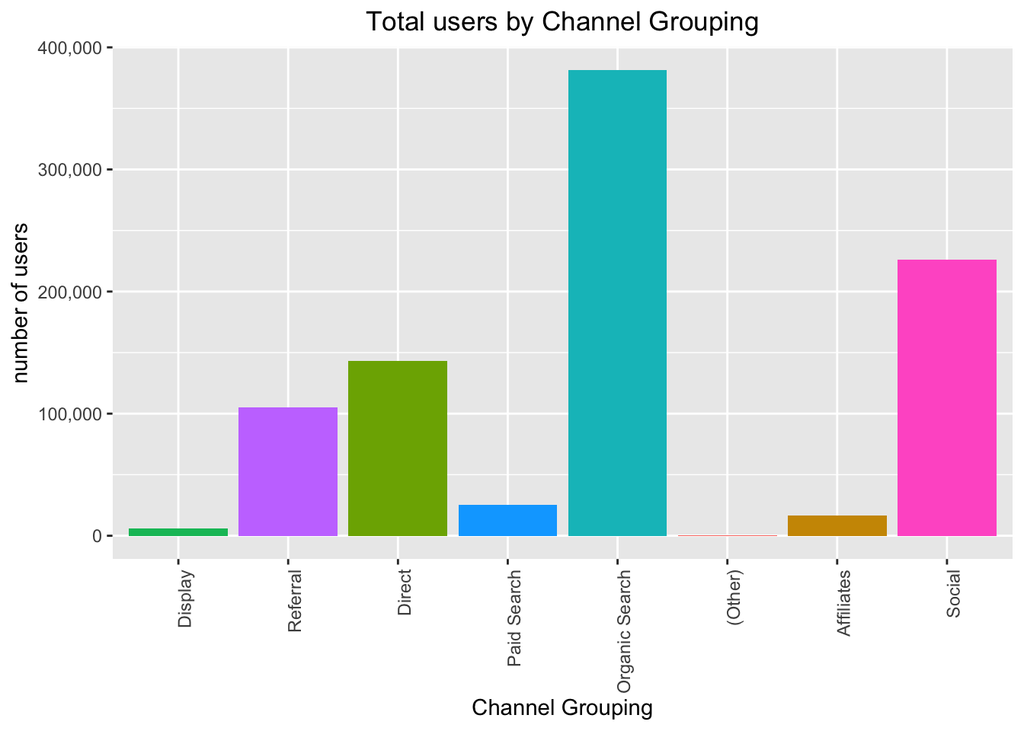

```r
cgp <- train %>%
  group_by(channelGrouping) %>%
  transmute(avg_revenue=mean(transactionRevenue)) %>%
  slice(1) %>%
  arrange(desc(avg_revenue))

cgno <- train %>%
  ggplot(aes(x=channelGrouping
             , fill=channelGrouping)) +
  geom_bar() +
  scale_x_discrete(limits=cgp$channelGrouping)+
  scale_y_continuous(labels=scales::comma)+
  theme(plot.title = element_text(hjust = 0.5), legend.position = "none")+
  theme(axis.text.x = element_text(angle = 90, hjust = 1)) +
  ggtitle("Total users by Channel Grouping") +
  labs(
    x='Channel Grouping',
    y='number of users')
cgno
```

*Insights*:

Please refer to the report for table showing the channels and their description if necessary.

From the plots, ‘Display’ has the highest average transaction revenue but the number of users that accessed via ‘Display’ is low. This is possibly due to the advertisements shown are targeted specifically according to the user’s search history or preferences. Hence, increasing the chances of users buying the products on the store.

Affiliate marketing have helped increased the number of users, however, the average transaction revenue earned was very low. Hence, this marketing method may seem like an ineffective. On the other hand, paid search is a more effective advertising campaign as the number of visits and average transaction revenue were higher.

Nevertheless, most of the users visited the website from Organic Search, little revenue was generated from this group of people. This may be a result of users wanting to just browse through the products without the intention of buying.

## 3.3.4 Medium Dimension

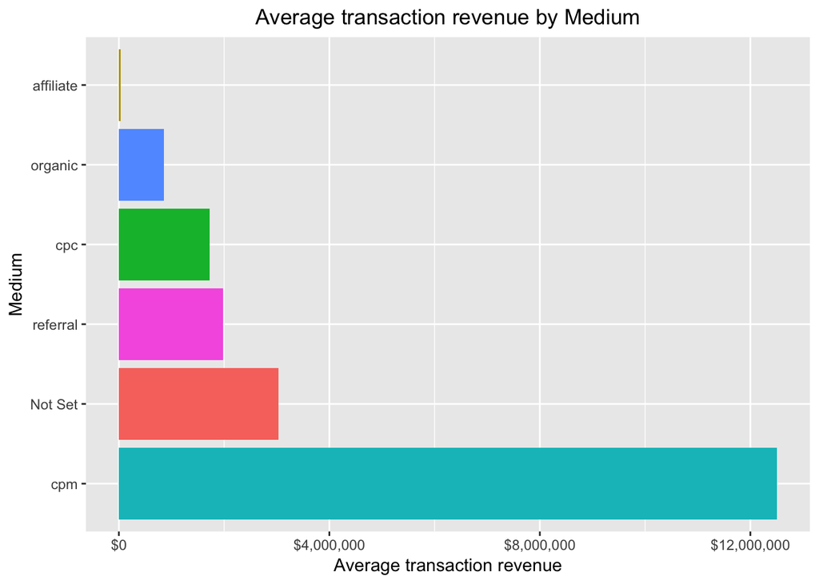

```r
plotmedium <- train %>%
  group_by(medium) %>%
  mutate(avg_revenue=mean(transactionRevenue)) %>%
  slice(1) %>%
  ungroup() %>%
  ggplot(aes(x=reorder(medium, -avg_revenue), y=avg_revenue, fill=medium)) +
  geom_col() +
  coord_flip()+
  scale_y_continuous(label=scales::dollar)+
  theme(plot.title = element_text(hjust = 0.5), legend.position ="none")+
  ggtitle("Average transaction revenue by Medium") +
  labs(
    x='Medium',
    y='Average transaction revenue')
plotmedium
```

```r
aggregate(transactionRevenue ~ medium, data = train, mean)
```

```
##      medium transactionRevenue
## 1   Not Set         3037811.33
## 2 affiliate           36418.95
## 3       cpc         1719928.14
## 4       cpm        12509974.45
## 5   organic          855382.26
## 6  referral         1983189.41
```

*Insights*:

The medium dimension is closely linked to the Channel Groupings variable as defined by Google Analytics and medium can determine the type of channel grouping. From the plot, cpm generates the highest average transaction revenue which matches the result we obtained from the 3.3.3 Channel Grouping plot. Cpm is a type of digital marketing and it refers to the cost of 1,000 advertisement impressions on one webpage. Since cpm is grouped under the Display channel, we can infer that cpm is the largest variable under the ‘Display’ channel and the biggest contributor of the average transaction revenue. Therefore, cpm was one of the most effective digital marketing strategy when compared to the other variables.

Explanation from https://www.investopedia.com/terms/c/cpm.asp

## 3.3.5 Device Categories

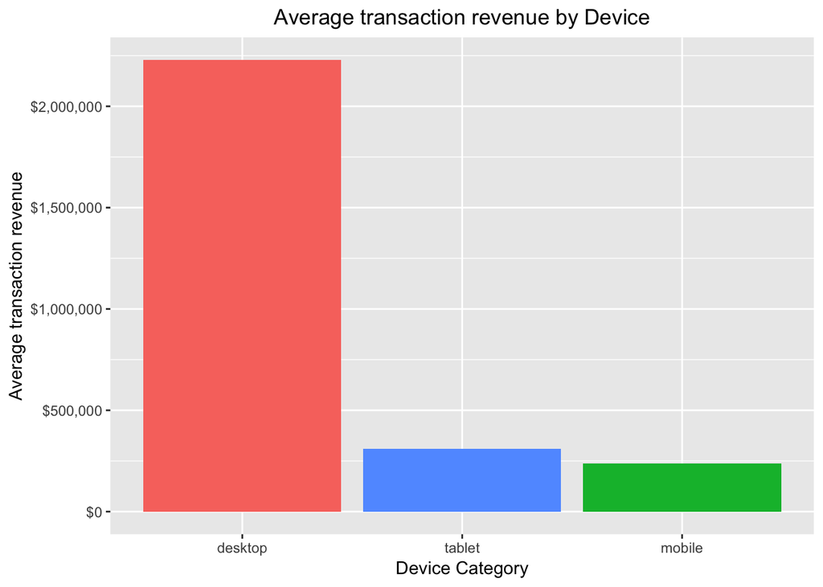

```r
plotdevice <- train %>%
  group_by(deviceCategory) %>%
  mutate(avg_revenue=mean(transactionRevenue)) %>%
  slice(1) %>%
  ungroup() %>%
  ggplot(aes(x=reorder(deviceCategory, -avg_revenue), y=avg_revenue, fill=deviceCategory)) +
  geom_col() +
  scale_y_continuous(label=scales::dollar)+
  theme(plot.title = element_text(hjust = 0.5), legend.position = "none")+
  ggtitle("Average transaction revenue by Device") +
  labs(
    x='Device Category',
    y='Average transaction revenue')
plotdevice
```

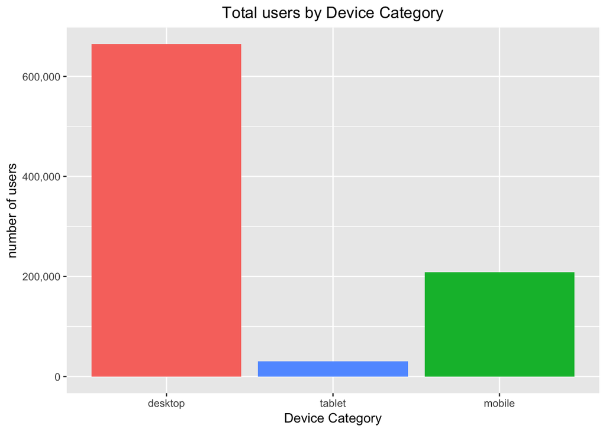

```r
devicep <- train %>%
  group_by(deviceCategory) %>%
  transmute(avg_revenue=mean(transactionRevenue)) %>%
  slice(1) %>%
  arrange(desc(avg_revenue))

deviceno <- train%>%
  ggplot(aes(x=deviceCategory, fill=deviceCategory)) +
  geom_bar() +
  scale_x_discrete(limits=devicep$deviceCategory)+
  scale_y_continuous(labels=scales::comma)+
  theme(plot.title = element_text(hjust = 0.5), legend.position = "none")+
  ggtitle("Total users by Device Category") +
  labs(
    x='Device Category',
    y='number of users')
deviceno
```

*Insights*:

From this plot, we derived that users using desktop generates the highest average transaction revenue. Perhaps this is because it is easier and more common for users to use desktops to make an online transaction as compared to the other two devices. According to an article on Forbes , people tend to do deep online research on a desktop instead of a mobile device. Furthermore, people do not usually made their purchases on a mobile device and it is merely used as a research tool throughout the purchase process. Hence, there is a higher transaction revenue for desktop user.

Article from https://www.forbes.com/sites/forbescommunicationscouncil/2018/03/23/12-major-differences-between-mobile-and-desktop-marketing/#4107a3205d6b

## 3.3.6 isMobile

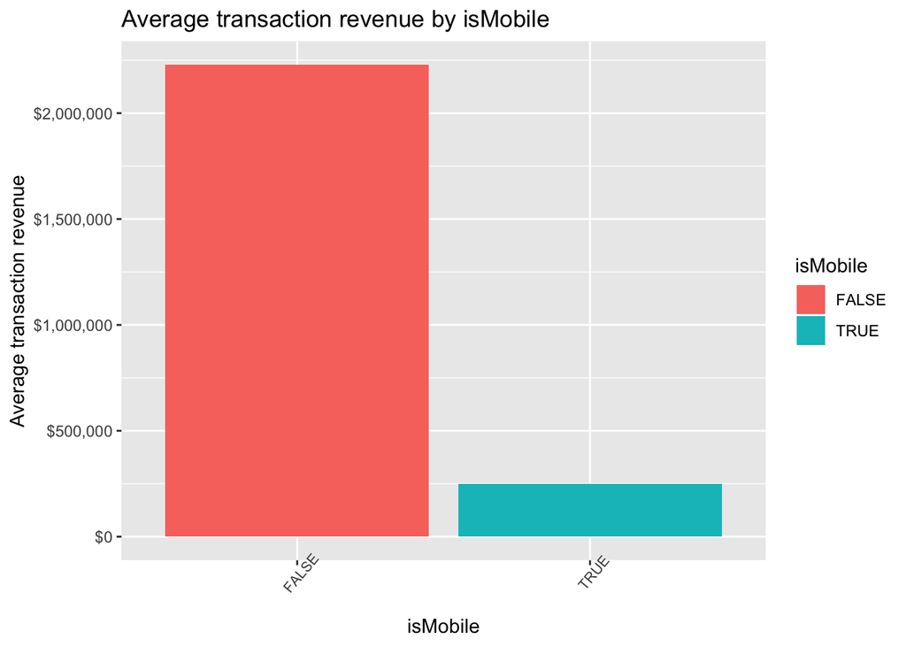

```r
Mobile <- train %>%
  group_by(isMobile) %>%
  mutate(avg_revenue=mean(transactionRevenue)) %>%
  slice(1) %>%
  ungroup() %>%
  ggplot(aes(x=reorder(isMobile, -avg_revenue), fill=isMobile, y=avg_revenue)) +
  geom_col() +
  scale_y_continuous(labels = scales::dollar) +
  ggtitle("Average transaction revenue by isMobile") +
  theme(axis.text.x = element_text(angle=50, size=8)) +
  labs(x="isMobile", y="Average transaction revenue")
plot(Mobile)
```

*Insights*:

isMobile is highly correlated to 3.3.5 Device Categories. 0 refers to average transaction revenue derived from customers using a non-mobile device (desktop). On the other hand, 1 refers to the average transaction revenue generated from customers using a mobile device, which includes mobile and tablet.

Higher average transaction revenue was generated when non-mobile devices were used and this result corresponds to the output in 3.3.5 Device Categories.

## 3.3.7 Operating System

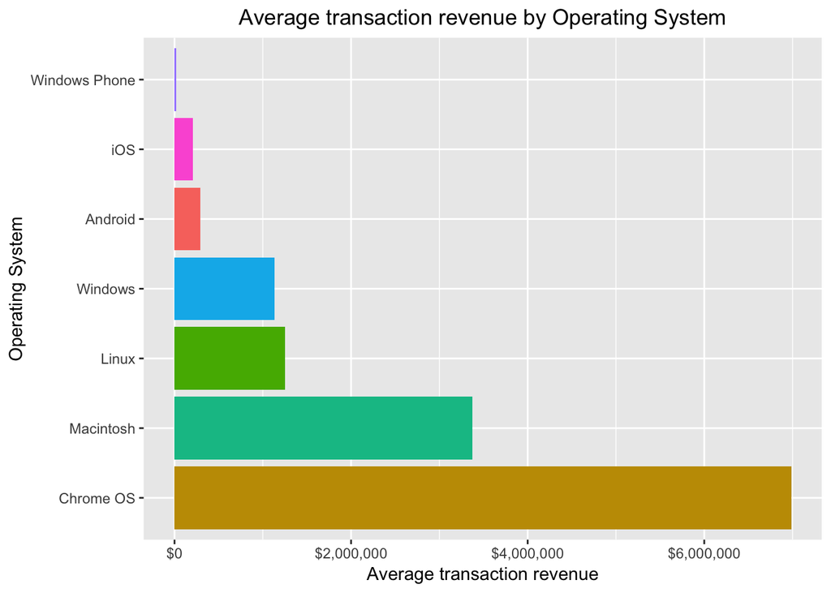

```r
plotOS <- train %>%
  group_by(operatingSystem) %>%
  mutate(avg_revenue=mean(transactionRevenue)) %>%
  slice(1) %>%
  ungroup() %>%
  top_n(n=7, avg_revenue) %>%
  ggplot(aes(x=reorder(operatingSystem, -avg_revenue), y=avg_revenue, fill=operatingSystem)) +
  geom_col() +
  coord_flip()+
  scale_y_continuous(label=scales::dollar)+
  theme(plot.title = element_text(hjust = 0.5), legend.position = "none")+
  ggtitle("Average transaction revenue by Operating System") +
  labs(
    x='Operating System',
    y='Average transaction revenue')
plotOS
```

```r
aggregate(transactionRevenue ~ operatingSystem, data = train, mean)
```

```
##    operatingSystem transactionRevenue
## 1          Android          293330.32
## 2       BlackBerry               0.00
## 3        Chrome OS         6984005.39
## 4       Firefox OS               0.00
## 5          FreeBSD               0.00
## 6            Linux         1253365.30
## 7        Macintosh         3372381.41
## 8       NTT DoCoMo               0.00
## 9     Nintendo 3DS               0.00
## 10    Nintendo Wii               0.00
## 11   Nintendo WiiU               0.00
## 12           Nokia               0.00
## 13         Not Set               0.00
## 14         OpenBSD               0.00
## 15         Samsung               0.00
## 16           SunOS               0.00
## 17         Windows         1134945.73
## 18   Windows Phone           21710.53
## 19            Xbox               0.00
## 20             iOS          205887.71
```

*Insights*:

This graph shows the 7 Operating Systems that have the highest average transaction revenue. Chrome OS takes the lead, followed by Macintosh and Linux in average transaction revenue.

Chrome OS is an operating system that was developed by Google. Hence, users who prefer Google’s product might have spent more and this led to a higher average transaction revenue amount.

## 3.3.8 Hits and Pageviews

*Insights*:

With higher hits and pageviews, the chances and amount of revenue transacted will increase. This maybe due to the fact that people were interested in the merchandises and they were spending more time on the website, looking for products to buy. Hence, we will be including these variables in our models.

## 3.4 Correlation Matrix

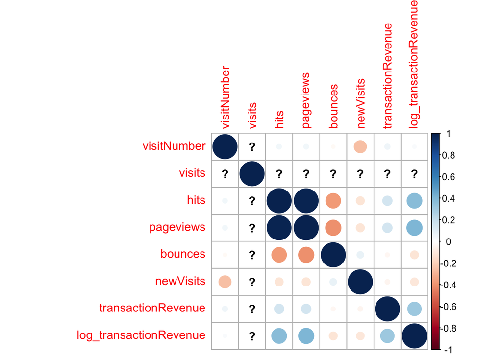

```r
library(corrplot)

train_nums <- dplyr::select_if(train, is.numeric)
train_nums <- as.matrix(train_nums)

corrplot(cor(train_nums))
```

*Interpretation*:

We see from this correlation matrix that only hits and pageviews are highly correlated. We should perhaps (1) decide whether we should use these two correlated variables in our model because it might add unnecessary weight or (2) use an algorithm that takes care of correlated variables.

The question mark that is seen for ‘visits’ is due to a constant value of ‘1’ with no standard deviation, which makes sense since each observation is counted as ‘1’ visit and not a sum of visits for that particular user. Thus, corrplot is not able to plot the correlation relating to ‘visits’.

# 4. Model Selection & Evaluation

## 4.1 Choice of Error Metric

```r
# RMSE formula
RMSE = function(m, o){
  sqrt(mean((m - o)^2))
}
```

*Explanation of choice of RMSE as error metric*:

We have opted to use root mean squared error as our error metric across our models because the Kaggle competition is using it. It is also common to use RMSE for regression-type models.

## 4.2 LASSO

*Explanation for using LASSO as exploratory model*:

Based on the variables identified above, our group set out to construct a regression model to predict the transaction revenue. Our group felt that there was a distinct positive relationship between our dependent variable(transaction revenue) and our independent variables (pageviews, hits, isMobile, channelGrouping, continent, visitNumber, medium). As such, a regression model was used as it is a simple model that estimates the relationship among the variables. The EDA conducted above provided us with some initution of which variables to use, however, our group felt that the model considered too many inputs and it may result in overfitting. Hence, we decided to run LASSO on our training set as it helps to identify and remove some variables.

An important aspect of LASSO’s algorithm is that it can provide a more accurate prediction by shrinking and eliminating coefficients that are not fitting, thus, this will assist in reducing variance. Additionally, the cross validation function in LASSO helps us to identify the best overall model. LASSO offers us two model options “lambda.min” - the best performing model and “lambda.1se” - the simplest model. Our group decided to use “lambda.min” , which consisted of 19 variables (Appendix 1) as it would result in the best performing model. Using the variables identified in “lambda.min”, we set out to predict our first entry for transactional revenue on the testing data.

```r
library(glmnet)
library(coefplot)

# Variables used
eq = as.formula("log_transactionRevenue ~ pageviews + hits + isMobile +
                channelGrouping + continent + visitNumber  +
                medium - 1")


# Data pre-processing

sub_train <- train[,c("pageviews", "hits", "isMobile", "channelGrouping",
                      "continent", "visitNumber", "medium"
                      , "log_transactionRevenue",
                      "fullVisitorId")]

sub_test <- test[,c("pageviews", "hits", "isMobile", "channelGrouping",
                    "continent", "visitNumber", "medium",
                    "fullVisitorId"
)]


sub_test$log_transactionRevenue <- 0

# Dummy variables and convert to model frame
x <- model.matrix(eq, data=sub_train)
y <- model.frame(eq, data=sub_train)[,"log_transactionRevenue"]

# LASSO model
set.seed(466846)
fit3 <- cv.glmnet(y = y,
                  x = x,
                  family = "gaussian",
                  alpha = 1,
                  type.measure = "mse", nfolds = 50)


# Plot LASSO
plot(fit3)

# RMSE
rmse_lasso <- sqrt(fit3$cvm[fit3$lambda == fit3$lambda.min])

# Coef of lambda.min and lambda.1se
coef(fit3, s= "lambda.min")
coef(fit3, s = "lambda.1se")

# Predict using test data
xvals <- model.matrix(eq, data=sub_test)
yvals <- model.frame(eq, data=sub_test)[,"log_transactionRevenue"]

pred <- predict(fit3, newx = xvals,type = "response",s="lambda.min")

# Submission processing
submission_lasso <- data.frame(sub_test$fullVisitorId, pred)

names(submission_lasso) <- c("fullVisitorId", "PredictedLogRevenue")

submission_lasso <- submission_lasso  %>% group_by(fullVisitorId)  %>%
  summarise(PredictedLogRevenue = sum(PredictedLogRevenue))

write.csv(submission_lasso, "submission_lasso4.csv", row.names = F)
```

[output not shown]

## 4.2.1 LASSO Model Evaluation

Our first entry yielded a root mean square error of 1.6410 which ranked us 2928 on the charts. Although this was a decent attempt, running a regression using LASSO has certain flaws. For instance, LASSO cannot identify the p-values for the coefficients, as such, we could not determine which variables were significant.

## 4.3 Random Forest

*Explanation for using Random Forest as exploratory model*:

The random forest algorithm was chosen as our group’s exploratory model because it produces a great result most of the time without advanced tuning of parameters. We have also determined the Google Store case as a combination of a classification and regression data science project, and this is where Random Forest shines in. Random forest can be used for both classification and regression, and the good thing is it is also relatively easy to code, even though it runs at a slow pace as more variables are added.

As an exploratory model, one important feature of the algorithm is the ability to determine the important variables so that we can prevent overfitting. Random Forest has ways of showing feature importance: (1) by IncNodePurity which is calculated by looking at a particular feature reduce impurity across all trees in the forest and (2) by IncMSE which is the shows the increase in mean-squared error of predictions (estimated with out-of-bag cross validation) as a result of variable j being permuted. IncNodePurity is biased and IncMSE, the more robust and informative measure, should almost always be used. However, the limitation is that IncMSE takes a longer time to compute.

Source from https://stats.stackexchange.com/questions/162465/in-a-random-forest-is-larger-incmse-better-or-worse

The ranger package was used because it optimises for larger dimensions of data, which the traditional randomForest package in r does not.

```r
# Random Forest using ranger package
library(ranger)

set.seed(1)
# Variables used
rf.train.1 <- train[, c("channelGrouping", "continent", "pageviews","visitNumber"
                        , "hits")]

rf.label <- train$log_transactionRevenue

# RF Model
rf.1 <- ranger(rf.label~., num.trees = 500, data = rf.train.1,
               importance = "permutation", verbose = FALSE)



# Summary of model
rf.1
```

```
## Ranger result
##
## Call:
##  ranger(rf.label ~ ., num.trees = 500, data = rf.train.1, importance = "permutation",      verbose = FALSE)
##
## Type:                             Regression
## Number of trees:                  500
## Sample size:                      903653
## Number of independent variables:  5
## Mtry:                             2
## Target node size:                 5
## Variable importance mode:         permutation
## Splitrule:                        variance
## OOB prediction error (MSE):       2.819161
## R squared (OOB):                  0.2978177
```

```r
# Variable importance
rf.1$variable.importance
```

```
## channelGrouping       continent       pageviews     visitNumber
##      0.29137425      0.46716208      1.22798322      0.06077347
##            hits
##      0.43579928
```

```r
# RMSE
paste0("RMSE is ", sqrt(rf.1$prediction.error),".")
```

```
## [1] "RMSE is 1.67903561517499."
```

```r
# Predict using test data
rf.test.1 <- test[, c("channelGrouping", "continent", "pageviews",
                      "visitNumber", "fullVisitorId", "hits")]

pred2 <- predict(rf.1, rf.test.1, type = "response")

# Submission processing
submission_ranger <- data.frame(rf.test.1$fullVisitorId, pred2$predictions)

names(submission_ranger) <- c("fullVisitorId", "PredictedLogRevenue")


submission_ranger <- submission_ranger  %>% group_by(fullVisitorId)  %>%
  summarise(PredictedLogRevenue = sum(PredictedLogRevenue))


write.csv(submission_ranger, file = "submission_ranger.csv", row.names = F)
```

*Interpretation of results*:

After iterations of finding the best variables based on IncMSE or ‘permutation’ importance in ranger, we obtained a RMSE on Kaggle of 1.6472. We did not do very well with the random forest, perhaps it is due to a coding error (we realised it was due to wrong removal of duplicates) or wrong choice of variables.

## 4.4 Insights from initial models

This might come as no surprise, as only users who are more interested in the products will have higher pageviews and hits. In addition, users from the subContinent ‘North America’ and certain countries have a higher frequency of users purchasing items too.

# 5. Classification of users into paying and non-paying

*Comments*:

There are only 11,515 visits with revenue as mentioned above, which is only 1.27% of the total observations from the train data. This matches the number of missing values found in transaction revenue previously. Our previous models were attempting to explain variations of these observations with transaction revenue. However, this means that we are only explaining a very small portion of the data. Thus, we will be classifying our observations into two categories: transaction revenue, and no transaction revenue.

As a result, we will first run a model that identifies whether a visitor will make a transaction and then predict the amount of revenue generated from the visitor.

# 6. Exploratory Data Analysis (Part II)

We will analyse the data again after the data has been classified into their categories accordingly. For those who transacted, we assigned a value of 1 and for those visitors who did not transact, we assigned a value of 0.

```r
# Classify those that buy and those that don't buy
train_class <- train %>% mutate(target_class = ifelse(as.numeric(transactionRevenue) > 0, 1, 0))
```

## 6.1 Channel Grouping

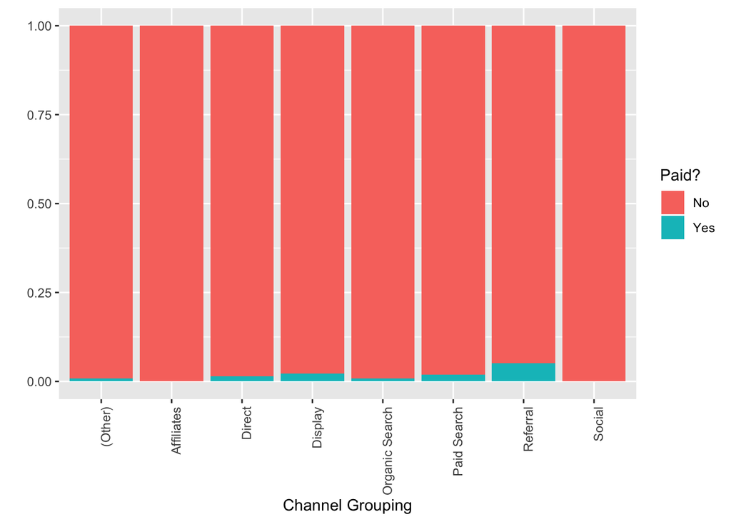

```r
plotCG2 <- train_class %>%
  group_by(channelGrouping, target_class) %>%
  summarise(n=n()) %>%
  mutate(prop=n/sum(n)) %>%
  ggplot(aes(x=channelGrouping, y=prop, fill=factor(target_class)))+
  geom_bar(stat="identity", position="fill")+
  theme(plot.title = element_text(hjust = 0.5))+
  theme(axis.text.x = element_text(angle = 90, hjust = 1)) +
  labs(
    x='Channel Grouping', y='')+
  scale_fill_discrete(name="Paid?",labels=c("No", "Yes"))
plotCG2
```

*Comments*:

This plot shows that certain channel groupings such as ‘Referral’ and ‘Display’ have a higher proportion of paying customers in their own categories. Perhaps the effectiveness of word-of-mouth marketing is demonstrated through referrals. This is consistent with what we found with our exploratory models and we will keep this variable.

## 6.2 Medium

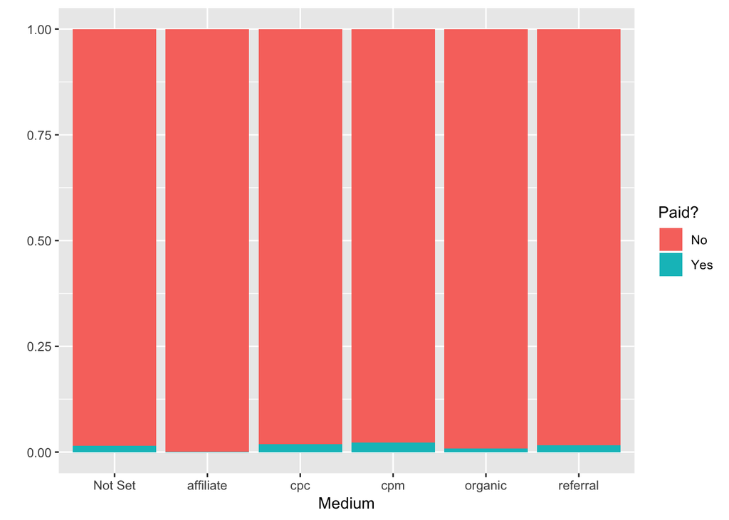

```r
plotmedium2 <- train_class %>%
  group_by(medium, target_class) %>%
  summarise(n=n()) %>%
  mutate(prop=n/sum(n)) %>%
  ggplot(aes(x=medium, y=prop, fill=factor(target_class)))+
  geom_bar(stat="identity", position="fill")+
  theme(plot.title = element_text(hjust = 0.5))+
  labs(
    x='Medium', y='')+
  scale_fill_discrete(name="Paid?",labels=c("No", "Yes"))
plotmedium2
```

*Comments*:

This variable ‘medium’ might explain some variation due to ‘cpm’ and ‘cpc’ variables having slightly higher proportions. We can test this variable’s importance later on, or feature engineer it along with another variable.

## 6.3 Device Category

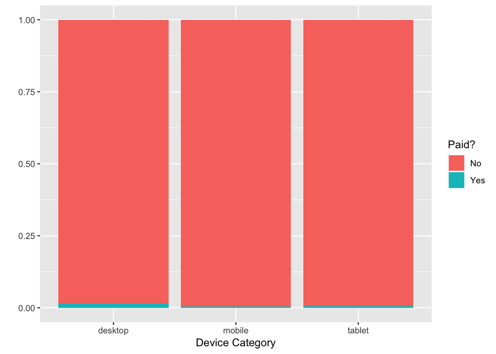

```r
plotdevice2 <- train_class %>%
  group_by(deviceCategory, target_class) %>%
  summarise(n=n()) %>%
  mutate(prop=n/sum(n)) %>%
  ggplot(aes(x=deviceCategory, y=prop, fill=factor(target_class)))+
  geom_bar(stat="identity", position="fill")+
  theme(plot.title = element_text(hjust = 0.5))+
  labs(
    x='Device Category', y='')+
  scale_fill_discrete(name="Paid?",labels=c("No", "Yes"))
plotdevice2
```

*Comments*:

For Device category, the proportion of paying customers is the highest for desktop which is possibly due to desktop being a common means to shop as compared to the other two devices, as mentioned in 3.3.5 Device Categories. We will feature engineer a binary variable for desktop to include it in the model.

## 6.4 Operating System

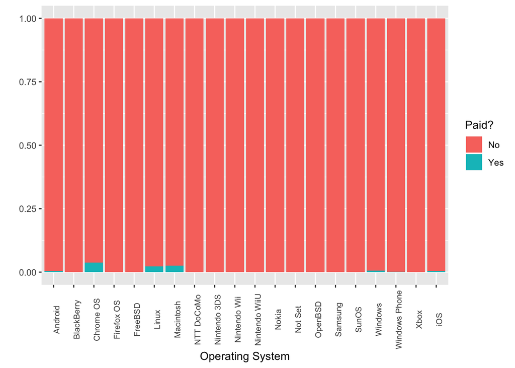

```r
plotOS2 <- train_class %>%
  group_by(operatingSystem, target_class) %>%
  summarise(n=n()) %>%
  mutate(prop=n/sum(n)) %>%
  ggplot(aes(x=operatingSystem, y=prop, fill=factor(target_class)))+
  geom_bar(stat="identity", position="fill")+
  theme(plot.title = element_text(hjust = 0.5), axis.text.x = element_text(angle=90, size=8))+
  labs(
    x='Operating System', y='')+
  scale_fill_discrete(name="Paid?",labels=c("No", "Yes"))
plotOS2
```

```r
OS2 <- train_class %>%
  group_by(operatingSystem, target_class) %>%
  summarise(n=n()) %>%
  mutate(prop=n/sum(n))
```

*Comments*:

## 6.5 Continent

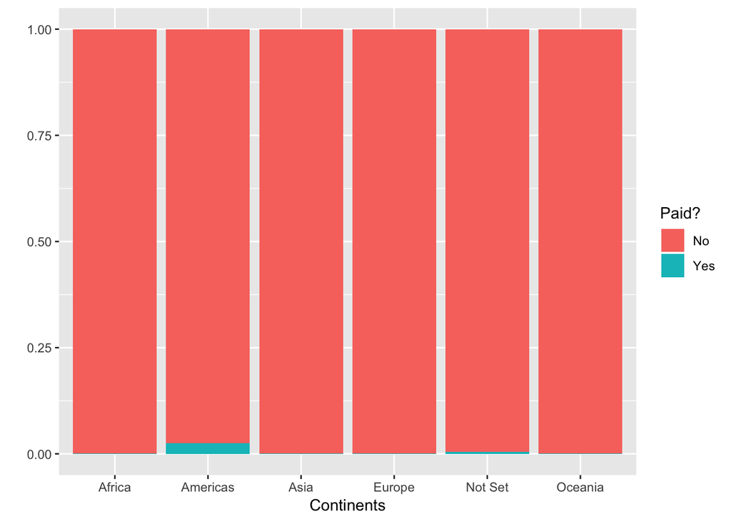

```r
plotcontinent2 <- train_class %>%
  group_by(continent, target_class) %>%
  summarise(n=n()) %>%
  mutate(prop=n/sum(n)) %>%
  ggplot(aes(x=continent, y=prop, fill=factor(target_class)))+
  geom_bar(stat="identity", position="fill")+
  theme(plot.title = element_text(hjust = 0.5))+
  labs(
    x='Continents', y='')+
  scale_fill_discrete(name="Paid?",labels=c("No", "Yes"))
plotcontinent2
```

*Comments*:

Similar to the results obtained from the Continent plot in Exploratory Data Analysis, Americas shows the highest proportion of paying customers.

## 6.6 subContinent

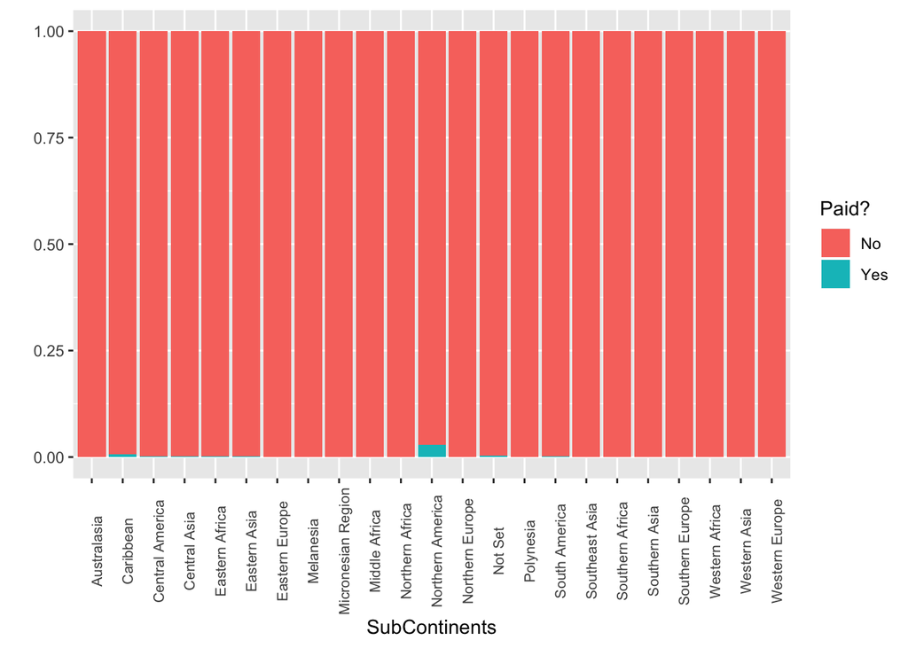

```r
plotsubcontinent2 <- train_class %>%
group_by(subContinent, target_class) %>%
summarise(n=n()) %>%
mutate(prop=n/sum(n)) %>%
ggplot(aes(x=subContinent, y=prop, fill=factor(target_class)))+
geom_bar(stat="identity", position="fill")+
theme(plot.title = element_text(hjust = 0.5), axis.text.x = element_text(angle=90, size=8))+
labs(
x='SubContinents', y='')+
scale_fill_discrete(name="Paid?",labels=c("No", "Yes"))
plotsubcontinent2
```

*Insights*:

From this graph, it appears that although the Americas have the highest proportion of paying visitors, the proportion is particularly high for visitors from Northern America.

## 6.7 Country

Due to the above results, we also looked into the proportion of paying visitors for different countries. As there are too many countries included in the dataset, it is impossible to plot a useful graph of the distribution. However, it is noted that United States of America have the highest proportion of visitors. This is likely due to Google being founded in the United States and hence, the greater interest in purchasing Google merchandise.

## 6.8 Pageviews & Hits

In our first EDA, we had expected pageviews and hits to be useful variables in predicting transaction revenue and this was confirmed through the %IncMSE measure of our earlier Random Forest model. We will hence be including them in our revised model.

## 6.9 Browser

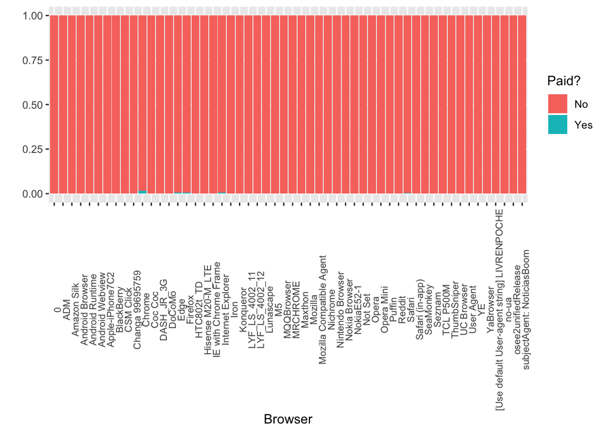

```r
plotbrowser2 <- train_class %>%
group_by(browser, target_class) %>%
summarise(n=n()) %>%
mutate(prop=n/sum(n)) %>%
ggplot(aes(x=browser, y=prop, fill=factor(target_class)))+
geom_bar(stat="identity", position="fill")+
theme(plot.title = element_text(hjust = 0.5), axis.text.x = element_text(angle=90, size=8))+
labs(
x='Browser', y='')+
scale_fill_discrete(name="Paid?",labels=c("No", "Yes"))
plotbrowser2
```

*Insights*:

Chrome users have the highest proportion of visitors with transaction revenue. This may be because it is the category with the most users and Chrome is also the browser of Google, which might signify that Google fans are more likely to purchase from GStore.

# 7 Model Evaluation & Refinement

## 7.1 Feature Engineering

*Approach*:

One way to improve on our model is to do some feature engineering. For instance, we can look at the graphs that fills the portion of users who purchased something as ‘1’ and others as ‘0’. We noted that perhaps browser == Chrome may have some predictive power.

Another insight we got from EDA is that users with features (deviceCategory == desktop & operatingSystem == “Chrome OS”, “Macintosh” or “Linux”) tend to buy more than other combinations. As such, we will make a binary variable that separates these combinations from the rest.

```r
train$browser_Chrome <-
  ifelse(train$browser == "Chrome", 1, 0)

test$browser_Chrome <-
  ifelse(test$browser == "Chrome", 1, 0)

train$desktop_CLM <- ifelse(train$deviceCategory == "desktop" & train$operatingSystem == "Macintosh"
                                      | train$deviceCategory == "desktop" & train$operatingSystem == "Linux"
                                      | train$deviceCategory == "desktop" & train$operatingSystem == "Chrome OS", 1,0)
test$desktop_CLM <- ifelse(test$deviceCategory == "desktop" & test$operatingSystem == "Macintosh"
                            | test$deviceCategory == "desktop" & test$operatingSystem == "Linux"
                            | test$deviceCategory == "desktop" & test$operatingSystem == "Chrome OS", 1,0)
```

## 7.2 Revised Random Forest Model

```r
library(ranger)

set.seed(1)

# Variables used
rf.train.2 <- train[, c("channelGrouping", "country", "subContinent", "pageviews",
                  "hits", "browser_Chrome", "medium", "desktop_CLM")]

rf.label <- train$log_transactionRevenue

# Ranger model
rf.2 <- ranger(rf.label~., num.trees = 500, data = rf.train.2,
               importance = "permutation", verbose = FALSE)


# Load RDS object
rf.2 <- readRDS('rf.2.rds')
# Summary of model
rf.2
```

```
## Ranger result
##
## Call:
##  ranger(rf.label ~ ., num.trees = 500, data = rf.train.2, importance = "permutation",      verbose = FALSE)
##
## Type:                             Regression
## Number of trees:                  500
## Sample size:                      903653
## Number of independent variables:  8
## Mtry:                             2
## Target node size:                 5
## Variable importance mode:         permutation
## Splitrule:                        variance
## OOB prediction error (MSE):       2.865276
## R squared (OOB):                  0.2863314
```

```r
# Variable importance
rf.2$variable.importance
```

```
## channelGrouping         country    subContinent       pageviews
##      0.14240987      0.42899971      0.25866121      1.17011799
##            hits  browser_Chrome          medium     desktop_CLM
##      0.49985464      0.09413387      0.08996018      0.07158533
```

```r
# RMSE
paste0("RMSE is ", sqrt(rf.2$prediction.error),".")
```

```
## [1] "RMSE is 1.6927126883776."
```

```r
# Predict using test
rf.test.2 <- test[, c("channelGrouping", "country", "subContinent", "pageviews",
                  "hits", "browser_Chrome", "medium", "desktop_CLM", "fullVisitorId")]

pred4 <- predict(rf.2, rf.test.2, type = "response")

# Submission processing
submission_ranger <- data.frame(rf.test.2$fullVisitorId, pred4$predictions)

names(submission_ranger) <- c("fullVisitorId", "PredictedLogRevenue")

submission_ranger <- submission_ranger  %>% group_by(fullVisitorId)  %>%
  summarise(PredictedLogRevenue = sum(PredictedLogRevenue))

write.csv(submission_ranger, file = "submission_ranger2.csv", row.names = F)
```

# 7.3 Trial of new model - Gradient Boosting Machines (GBM)

*What is GBM and is it better than Random Forest?*:

The idea of boosting came from the idea to combine weak models to generate a powerful one. A weak model is one that is slightly better than random performance and through the development of weak learns that describe the remaining difficult observations, we generate an ultimate model that does pretty well. Gradient boosting involves three functions: (1) Loss function, (2) A weak learner to make predictions and (3) An additive model to add weak learners to minimise the loss function. Decision trees are used as the weak learner in GBM and the additive model adds trees with a gradient descent procedure, reducing the loss. Under GBM, we then have parameters to help refine the model, namely tree constraints, learning rate, stochastic gradient boosting and penalised gradient boosting.

Documentation available at https://cran.r-project.org/web/packages/gbm/gbm.pdf.

Both GBM and RF are ensemble learning methods. GBM and RF differ in the ways the trees are constructed: the order and the way results are averaged. It has been found that GBM performs better if the parameters are carefully tuned.

Code referenced from https://www.kaggle.com/tatianass/gbm-google-store-revenue.

```r
library(gbm)

# Variables used
features <- c("channelGrouping", "subContinent", "pageviews","visitNumber"
              , "hits", "desktop_CLM", "browser_Chrome")

train_gbm <- select(train, features)
test_gbm <- select(test, features)

# Pre-processing
test_gbm$fullVisitorId <- test$fullVisitorId

train_gbm <- train_gbm %>% mutate(transactionRevenue = as.numeric(train$transactionRevenue))

train_gbm$transactionRevenue <- log1p(train_gbm$transactionRevenue)

train_gbm$transactionRevenue[train_gbm$transactionRevenue < 0] <- 0

# Split train into training and validation
train.validation.split <- sample(2
                                 , nrow(train_gbm)
                                 , replace = TRUE
                                 , prob = c(0.7, 0.3))

train2 = train_gbm[train.validation.split == 1,]
validation = train_gbm[train.validation.split == 2,]

# GBM model

  gbm.model <- gbm(transactionRevenue ~ .
                   , distribution = "gaussian"
                   , data = train2
                   , n.trees = 1000
                   , interaction.depth = 3
                   , n.minobsinnode = 100
                   , shrinkage = 0.01
                   , bag.fraction = 0.5
                   , train.fraction = 0.7
                   , cv.folds = 10
                   , verbose = FALSE
  )

# Best model
best.iter = gbm.perf(gbm.model, method = "test")
```

[figure not shown]

```r
# Feature importance
gbm.feature.imp = summary(gbm.model, n.trees = best.iter, method = permutation.test.gbm)
```

[figure not shown]

```r
# Predict using validation data
gbm.test = predict(gbm.model, newdata = validation, n.trees = best.iter)

# RMSE
print(RMSE(validation$transactionRevenue, gbm.test))
```

```
## [1] 1.697086
```

```r
# Predict using test data
pred_gbm = predict(gbm.model, newdata = test_gbm, n.trees = best.iter)

# Submission processing
submission_gbm <- data.frame(rf.test.1$fullVisitorId, pred_gbm)

names(submission_gbm) <- c("fullVisitorId", "PredictedLogRevenue")

submission_gbm <- submission_gbm  %>% group_by(fullVisitorId)  %>%
  summarise(PredictedLogRevenue = sum(PredictedLogRevenue))

write.csv(submission_gbm, "submission_gbm5.csv", row.names = F)


# We found negative revenue, put negative PredictedLogRevenue to 0

submission_gbm$PredictedLogRevenue <- ifelse(submission_gbm$PredictedLogRevenue
                                             < 0, 0, submission_gbm$PredictedLogRevenue)

write.csv(submission_gbm, "submission_gbm6.csv", row.names = F)
```

*Insights*:

## 8. Conclusion

Our final model (GBM) ranked us at 2739 improving our ranking by over 100 positions from our initial rank of 2928. In general, the lower the RMSE, the better. Hence, our final RMSE value of 1.5387 depicted that our model’s predictive value was decent but it still had room for improvement.

In sum, the entire experience from start to finish was an insightful experience that further developed our analytical and problem solving skills. This project developed our ability to learn independently and encouraged us to discover new methods in analytics apart from what was taught in the classroom.

## 9. References

Please refer to our word document for Appendix I and additional references.